# Pertemuan 4 Praktikum MPDW

## Scatter Plot antar Lag

### Scatterplot Yt dengan Yt−1,Yt−2,Yt−3

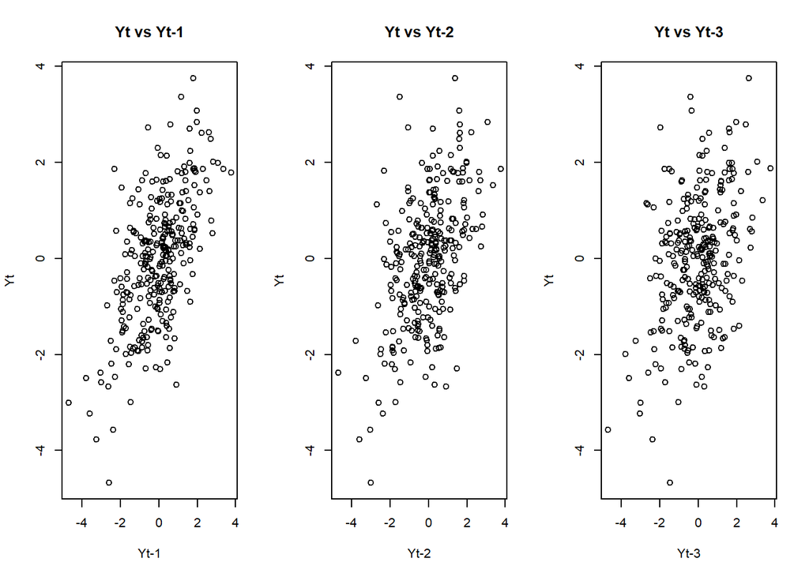

```r
par(mfrow=c(1,3))
plot(y_manual_ar[-1], y_manual_ar[-n], main="Yt vs Yt-1",
     xlab="Yt-1", ylab="Yt")
plot(y_manual_ar[-c(1:2)], y_manual_ar[-c((n-1):n)], main="Yt vs Yt-2",
     xlab="Yt-2", ylab="Yt")
plot(y_manual_ar[-c(1:3)], y_manual_ar[-c((n-2):n)], main="Yt vs Yt-3",
     xlab="Yt-3", ylab="Yt")
```

## Autokorelasi dari data bangkitan maupun teoritis

### Autokorelasi Data AR(2) Hasil Bangkitan

```r
acf_empiris_ar_manual <- acf(y_manual_ar, plot=FALSE)$acf[1:3]
acf_empiris_ar_manual
```

```
## [1] 0.5968974 0.5013913 0.3877849
```

```r
acf_empiris_ar_arima <- acf(y_arima_ar, plot=FALSE)$acf[1:3]
acf_empiris_ar_arima
```

```
## [1] 0.6750140 0.5256742 0.3713153
```

### Autokorelasi Teoritis AR(2)

```r
rho <- numeric(3)
rho[1] <- phi1 / (1 - phi2)                 # rho1
rho[2] <- phi1 * rho[1] + phi2              # rho2
rho[3] <- phi1 * rho[2] + phi2 * rho[1]     # rho3

rho
```

```
## [1] 0.62500 0.51250 0.38125
```

### Perbandingan Autokorelasi Empiris dan Teoritis

```r
data.frame(Lag=1:3, ACF_Empiris_manual=acf_empiris_ar_manual, ACF_Empiris_arima=acf_empiris_ar_arima ,ACF_Teoritis=rho)
```

```
##   Lag ACF_Empiris_manual ACF_Empiris_arima ACF_Teoritis
## 1   1          0.5968974         0.6750140      0.62500
## 2   2          0.5013913         0.5256742      0.51250
## 3   3          0.3877849         0.3713153      0.38125
```

Dari hasil di atas, dapat dilihat bahwa autokorelasi empiris mendekati autokorelasi teoritis untuk lag 1, 2, dan 3, yang menunjukkan bahwa model AR(2) yang dibangkitkan sesuai dengan karakteristik teoritisnya.

# 3. Bangkitkan model ARMA(2,2) dengan θ1=0.4 & θ2=0.6 & ϕ1=0.5 & ϕ2=0.2 sebanyak 300 data (Manual dan dengan arima.sim)

## Pembangkitan data ARMA(2,2) secara manual

```r
set.seed(125)  # biar hasil sama setiap run
n <- 300
phi1 <- 0.5
phi2 <- 0.2
theta1 <- 0.4
theta2 <- 0.6
# --- Cara manual ---
# epsilon ~ N(0,1)
eps <- rnorm(n + 2)
y_manual_arma <- numeric(n + 2)
for (t in 3:(n+2)) {
  y_manual_arma[t] <- phi1*y_manual_arma[t-1] + phi2*y_manual_arma[t-2] +
    eps[t] + theta1*eps[t-1] + theta2*eps[t-2]
}
y_manual_arma <- y_manual_arma[3:(n+2)]  # ambil data 300
y_manual_arma <- ts(y_manual_arma)
y_manual_arma
```

```
## Time Series:
## Start = 1
## End = 300
## Frequency = 1
##   [1]  2.164423260  1.576014098  2.738492622 -0.301105596 -0.603207373
##   [6] -1.679299269 -1.323068028 -0.547548455 -0.803968900  0.105723262
##  [11]  0.086674259  1.144865444  0.033263907  0.961165697  1.834844317
##  [16]  3.416948021  2.004253297  2.988564118  2.001263070  3.676244303
##  [21]  1.796113244  2.505418513  0.617983314  1.373642752 -1.198427988
##  [26] -0.281331459 -0.368602928  0.848478157  1.119978147  3.397795379
##  [31]  2.034648912  3.544969847  3.508371658  4.678781965  4.178165053
##  [36]  2.496804735  2.675455707 -0.080738678  0.673447190 -1.321696367
##  [41]  0.274322778 -1.570154316  0.011614992 -1.265420159 -1.159352393
##  [46] -1.872697082 -0.323572354 -0.878507230  0.873511369  1.097717000
##  [51]  1.899289852  2.939589152  3.230341821 -0.470537621  0.281527057
```

[output cut: 49 more lines]

## Pembangkitan data ARMA(2,2) dengan arima.sim

```r
# --- Cara dengan arima.sim ---
y_arima_arma <- arima.sim(model = list(ar = c(phi1, phi2), ma = c(theta1, theta2)), n = n)
y_arima_arma <- ts(y_arima_arma)
y_arima_arma
```

```
## Time Series:
## Start = 1
## End = 300
## Frequency = 1
##   [1] -1.421379688 -1.005599509 -0.692258341 -1.298181237 -1.849570137
##   [6] -3.564584579 -3.303707607 -4.095667748 -1.924619583 -2.766552693
##  [11]  0.308278253  2.194312860  3.573836721  2.819924350  2.325687391
##  [16]  2.063364729  0.356763407 -1.542089749 -2.577839286 -4.049097890
##  [21] -3.333008526 -3.011822000 -4.595465854 -2.943314082 -4.045772199
##  [26] -1.204422029 -1.224769556 -0.458750586 -1.549097311 -1.908746929
##  [31] -0.837081821 -0.869553399  0.592983672 -0.723822184  1.403311945
##  [36]  1.853271072  3.650568801  3.753859109  2.517462356  0.054170229
##  [41] -0.394931737 -2.480484378 -0.779874187 -2.086458082 -1.631144195
##  [46] -3.024360878 -3.358335698 -4.094243359 -4.520883156 -4.864049826
##  [51] -5.115975363 -4.064649897 -4.506878413 -2.554423180 -2.159857894
```

[output cut: 49 more lines]

## Karakteristik data ARMA(2,2)

### Plot Time Series, ACF, PACF, dan EACF

```
## AR/MA
##   0 1 2 3 4 5 6 7 8 9 10 11 12 13
## 0 x x x x x x x x o o o  o  o  o
## 1 x x x o o o o o o o o  o  o  o
## 2 x x o o o o o o o o o  o  o  o
## 3 x x o o o o o o o o o  o  o  o
## 4 x x o x o o o o o o o  o  o  o
## 5 x x x x x o o o o o o  o  x  o
## 6 x x x x o o x o o o o  o  o  o
## 7 x o x o x x o o o o o  o  o  o
```

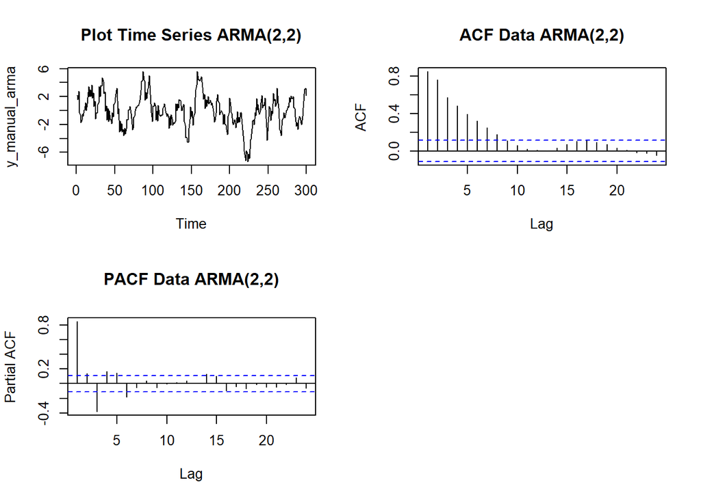

```r
library(TSA)   # untuk EACF
par(mfrow=c(2,2))
plot.ts(y_manual_arma, main="Plot Time Series ARMA(2,2)")
acf(y_manual_arma, main="ACF Data ARMA(2,2)")
pacf(y_manual_arma, main="PACF Data ARMA(2,2)")
eacf(y_manual_arma)
```

Rangkuman : 1). Data ARMA(2,2) yang dibangkitkan stasioner dalam rataan berdasarkan plot time series, 2). ACF menunjukkan pola tails off karena keberadaan komponen AR, 3). PACF menunjukkan tidak adanya pola cut off, menunjukkan keberadaan komponen MA, 4). EACF menunjukkan pola segitiga pada baris ke-2.

## Scatter Plot antar Lag

### Scatterplot Yt dengan Yt−1,Yt−2,Yt−3

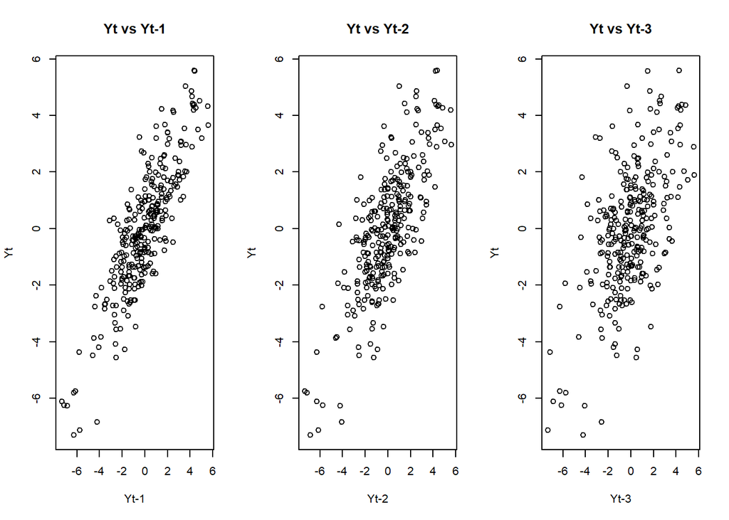

```r
par(mfrow=c(1,3))
plot(y_manual_arma[-1], y_manual_arma[-n], main="Yt vs Yt-1",
     xlab="Yt-1", ylab="Yt")
plot(y_manual_arma[-c(1:2)], y_manual_arma[-c((n-1):n)], main="Yt vs Yt-2",
     xlab="Yt-2", ylab="Yt")
plot(y_manual_arma[-c(1:3)], y_manual_arma[-c((n-2):n)], main="Yt vs Yt-3",
     xlab="Yt-3", ylab="Yt")
```

## Autokorelasi dari data bangkitan

### Autokorelasi Data ARMA(2,2) Hasil Bangkitan

```r
acf_empiris_arma_manual <- acf(y_manual_arma, plot=FALSE)$acf[1:10]
acf_empiris_arma_manual
```

```
##  [1] 0.85044499 0.76192371 0.57272025 0.48221059 0.39295581 0.32099909
##  [7] 0.24818014 0.17454804 0.10846898 0.06048511
```

```r
acf_empiris_arma_arima <- acf(y_arima_arma, plot=FALSE)$acf[1:10]
acf_empiris_arma_arima
```

```
##  [1] 0.87235358 0.73964113 0.52409636 0.37281664 0.24755969 0.14364004
##  [7] 0.08352844 0.03010269 0.03000288 0.02480939
```

### Autokorelasi Teoritis ARMA(2,2)

```r
# Parameter ARMA(2,2)
phi <- c(0.5, 0.2)        # phi1=0.5, phi2=0.2
theta <- c(0.4, 0.6)      # theta1=0.4, theta2=0.6

# Autokorelasi teoritis sampai lag 10
acf_theoretical <- ARMAacf(ar=phi, ma=theta, lag.max=10, pacf=FALSE)

acf_theoretical
```

```
##          0          1          2          3          4          5          6
## 1.00000000 0.85919932 0.74919080 0.54643526 0.42305579 0.32081495 0.24501863
##          7          8          9         10
## 0.18667231 0.14233988 0.10850440 0.08272018
```

### Perbandingan Autokorelasi Empiris dan Teoritis

```r
data.frame(Lag=1:10, ACF_Empiris_manual=acf_empiris_arma_manual, ACF_Empiris_arima=acf_empiris_arma_arima ,ACF_Teoritis=acf_theoretical[-1])
```

```
##    Lag ACF_Empiris_manual ACF_Empiris_arima ACF_Teoritis
## 1    1         0.85044499        0.87235358   0.85919932
## 2    2         0.76192371        0.73964113   0.74919080
## 3    3         0.57272025        0.52409636   0.54643526
## 4    4         0.48221059        0.37281664   0.42305579
## 5    5         0.39295581        0.24755969   0.32081495
## 6    6         0.32099909        0.14364004   0.24501863
## 7    7         0.24818014        0.08352844   0.18667231
## 8    8         0.17454804        0.03010269   0.14233988
## 9    9         0.10846898        0.03000288   0.10850440
## 10  10         0.06048511        0.02480939   0.08272018
```